# HUDM 6122 Final Project

Yixin Li, Elena Liu

2022-05-01

## Introduction

Exploratory Factor Analysis is a technique that is used to reduce data to a smaller set of summary variables and to explore the underlying theoretical structure of the phenomena. It is used to identify the structure of the relationship between the variable and the respondent. This is a strong appeal in analyzing the relationship between behaviors and social science related fields in exploring non-observable traits based on observable variability on behaviors.

Exploratory factor analysis (EFA) is generally used to discover the factor structure of a measure and to examine its internal reliability (latent variables). Exploratory factor analysis has three basic decision points: (1) decide the number of factors, (2) choosing an extraction method, (3) choosing a rotation method.

1. Decide the number of factors To decide the number of factors, the scree plot is the most common way. Scree plot is a two-dimensional graph with factors on the x-axis and eigenvalue that represents the variance accounted by each latent factors on the y-axis. We can tell from the plot that how much each factors account for total variance (for having the biggest eigenvalues) and decide how many factors supposed to be used in the following steps. The process of decision involves subjective judgement.
2. Choosing an extraction method There are two mathematical solutions for the extraction method. The first one is PCA, which assumes there is no measurement error existed, which is the true factor analysis. The second one is Maximum Likelihood Estimation. MLE assumes that Factor is with the standard normal distribution. Thus, X (i)∼ N (0, Ψ + T(w)* w). This means that the log-likelihood is L = − np /2* log (2π)− n* 2 log |Ψ + T(w)* w | − n /2 *tr((Ψ +T(w)* w) ^-1*V ). There are substantial difference between these two approaches, the normally distributed X makes more sense in extracting with the MLE estimation.
3. choosing a rotation method Rotation is a way that maximizing the higher loading and minimizing the lower ones which to achieve the simplest structure. There are two types of rotations, one is orthogonal rotation, which we used with ‘rotation = varimax’ in R as an example, but other rotation such as quartamax, equamax are also orthogonal rotation. Orthogonal rotation assumes that there are no correlations between the factors. Oblique rotation, exampled as “rotation = oblimin” is derived that the factors are somehow correlated, which gives the loading with the correlations between factors as a consideration. Oblique rotation is more practical in the real world for the cases of measurement. For better comparing the higher loadings and lower loadings, we will use varimax rotation method. Varimax rotation removes the middle ground and simplifies the loadings of items.

Advantages of Exploratory Factor Analysis: There are several advantages of EFA. The very first one is its ability on reduction of variables. We can find the inter-relationship of the variables, and dividing them into groups, and combining them into a single, or two factors. Exploratory Factor Analysis can also identify the hidden patterns beyond the observations, which may not be reflected from the direct analysis, and since the interpretation and choice of factors are subjective, its flexibility contributes to the various needs in the social science related analysis.

## Data Description

This data set is likert scale data which was collected based on survey questions of factors that influence customers’ buying decisions while purchasing a car. Customers can give points to the variables and the points are scaled from 1 to 5 with 1 being very low and 5 being very high. There are 90 responses and 14 variables in this data set. The 14 variables are Price, Safety, Exterior looks, Space and comfort, Technology, After sales service, Resale value, Fuel type, Fuel efficiency, Color, Maintenance, Test drive, Product reviews and Testimonials. All the 14 variables are categorical.

The goal for our project is to reduce the variables into numbers of factors so that the dataset will be more manageable. In order to do that, we will conduct factor analysis. There are three packages that will be used during our analysis which are “psych”, “parameters” and “nFactors”. “psych” is for factor analysis and principal component analysis, “parameters” is to report results of Barlett’s sphericity test and “nFactors” is to determine the number of factors for parallel analysis.

Before conducting factor analysis, we will need to measure the factorability of the data by using Kaiser-Meyer-Olkin(KMO). Once KMO’s guideline indicates our dataset is adequate for factor analysis, we will use Barlett’s sphericity test to see if factor analysis is useful with our data. If the factorbility of the data set is satisfied, we will use three methods, Eigenvalues, Scree plot and parallel analysis, to determine how many factors to be extracted. Next, we will use three functions to conduct factor analysis, which are principal, fa and factanal functions. Different factoring methods will be applied in the function. For example, we will use principal factor analysis and minimum residual. We will also use different rotation methods such as varimax and oblimin, which varimax rotation returns orthogonal factors and oblimin returns non-orthogonal factors.

## Analysis

#### Packages

```r
library(psych)
library(parameters)
library(nFactors)
library(factoextra)
```

#### Data Preprocessing

```r
data <- read.csv(file.choose())
head(data)
```

```
##   Price Safety Exterior_Looks Space_comfort Technology After_Sales_Service
## 1     4      4              5             4          3                   4
## 2     3      5              3             3          4                   4
## 3     4      4              3             4          5                   5
## 4     4      4              4             3          3                   4
## 5     5      5              4             4          5                   4
## 6     4      4              5             3          4                   5
##   Resale_Value Fuel_Type Fuel_Efficiency Color Maintenance Test_drive
## 1            5         4               4     2           4          2
## 2            3         4               3     4           3          2
## 3            5         4               5     4           5          4
## 4            5         5               4     4           4          2
## 5            5         3               4     5           5          5
## 6            3         4               3     2           3          2
##   Product_reviews Testimonials
## 1               4            3
## 2               2            2
## 3               4            3
## 4               5            3
## 5               5            2
## 6               2            3
```

```r
#dimension of the dataset
dim(data)
```

```
## [1] 90 14
```

```r
# The dataset have 90 samples and 14 variables.
```

#### KMO

###### We will use KMO(Kaiser-Meyer-Olkin) to measure if we can conduct factor analysis to the sample data.

```r
(kmo <- KMO(data))
```

```
## Kaiser-Meyer-Olkin factor adequacy
## Call: KMO(r = data)
## Overall MSA =  0.61
## MSA for each item =
##               Price              Safety      Exterior_Looks       Space_comfort
##                0.72                0.47                0.55                0.61
##          Technology After_Sales_Service        Resale_Value           Fuel_Type
##                0.65                0.62                0.63                0.68
##     Fuel_Efficiency               Color         Maintenance          Test_drive
##                0.62                0.56                0.61                0.64
##     Product_reviews        Testimonials
##                0.69                0.50
```

###### According to Kaiser’s guidelines, KMO values between 0.8 and 1 suggest the sampling is adequate, KMO values less than 0.6 indicate the sampling is not adequate for proceeding factor analysis. The KMO we got is 0.61 which is greater than 0.6 so we can conclude that factor analysis is adequate for our sample data.

#### Barlett’s Sphericity test

###### Then, we will apply Barlett’s sphericity test to check if factor analysis is useful with our data.

###### Null hypothesis: the variables are orthogonal(not correlated)

###### Alternative hypothesis: variables are not orthogonal(correlated enough to where the correlation matrix diverges significantly from the identity matrix)

```r
check_sphericity_bartlett(data)
```

```
## # Test of Sphericity
##
## Bartlett's test of sphericity suggests that there is sufficient significant correlation in the data for factor analysis (Chisq(91) = 247.71, p < .001).
```

###### Since the p value is smaller than 0.001, we can reject the null hypothesis and conclude that there is sufficient significant correlation in the data for factor analysis. Thus, the factor analysis is useful with our data.

###### After checking factorability of the data and redundancy between variables, We will use three ways to determine how many factors to extract.

#### Eigenvalues

```r
# Correlation matrix of the dataset
(r <- cor(data))
```

```
##                           Price       Safety Exterior_Looks Space_comfort
## Price                1.00000000 -0.090036923     0.01569499    0.11749470
## Safety              -0.09003692  1.000000000    -0.08189080    0.24199145
## Exterior_Looks       0.01569499 -0.081890804     1.00000000    0.16873315
## Space_comfort        0.11749470  0.241991449     0.16873315    1.00000000
## Technology           0.01465794  0.024151524     0.07086880    0.27577204
## After_Sales_Service  0.05400195  0.204918345     0.03337075    0.31667034
## Resale_Value         0.37611034 -0.190679342    -0.05841954   -0.21207031
## Fuel_Type            0.13837803  0.146572787     0.05157349    0.47817954
## Fuel_Efficiency      0.27958435 -0.140758547    -0.13606685    0.12523940
## Color                0.08330080 -0.061001201    -0.33296343   -0.13060065
## Maintenance          0.30264206 -0.200373172    -0.11034232    0.06685549
## Test_drive          -0.02588497  0.003159262     0.16025775    0.18552216
## Product_reviews      0.28054795 -0.067164826     0.04855372    0.23200808
## Testimonials        -0.11373884 -0.076573972     0.11135180    0.15777800
##                      Technology After_Sales_Service Resale_Value   Fuel_Type
## Price                0.01465794          0.05400195   0.37611034  0.13837803
## Safety               0.02415152          0.20491834  -0.19067934  0.14657279
## Exterior_Looks       0.07086880          0.03337075  -0.05841954  0.05157349
## Space_comfort        0.27577204          0.31667034  -0.21207031  0.47817954
## Technology           1.00000000          0.28136978  -0.06866963  0.21387357
## After_Sales_Service  0.28136978          1.00000000   0.08396205  0.25870042
## Resale_Value        -0.06866963          0.08396205   1.00000000 -0.04884261
## Fuel_Type            0.21387357          0.25870042  -0.04884261  1.00000000
## Fuel_Efficiency      0.02916502          0.41723372   0.32670224  0.14890402
## Color                0.06610285          0.09105182   0.12295497 -0.03515735
## Maintenance          0.18608561          0.14327118   0.43912788  0.02449635
## Test_drive           0.05709010          0.21652949   0.02131848  0.02393058
## Product_reviews      0.10323339          0.09823222   0.11287309  0.05725130
## Testimonials         0.05478557          0.01032813  -0.22827795  0.01946699
##                     Fuel_Efficiency       Color Maintenance   Test_drive
## Price                    0.27958435  0.08330080  0.30264206 -0.025884971
## Safety                  -0.14075855 -0.06100120 -0.20037317  0.003159262
## Exterior_Looks          -0.13606685 -0.33296343 -0.11034232  0.160257751
## Space_comfort            0.12523940 -0.13060065  0.06685549  0.185522158
## Technology               0.02916502  0.06610285  0.18608561  0.057090099
## After_Sales_Service      0.41723372  0.09105182  0.14327118  0.216529487
## Resale_Value             0.32670224  0.12295497  0.43912788  0.021318479
## Fuel_Type                0.14890402 -0.03515735  0.02449635  0.023930578
## Fuel_Efficiency          1.00000000  0.35220668  0.29813872  0.284495798
## Color                    0.35220668  1.00000000  0.37497769  0.081110516
## Maintenance              0.29813872  0.37497769  1.00000000  0.136595696
## Test_drive               0.28449580  0.08111052  0.13659570  1.000000000
## Product_reviews          0.34658011  0.19464404  0.31326502  0.179463899
## Testimonials             0.07091653  0.15474057 -0.11895190  0.252200843
##                     Product_reviews Testimonials
## Price                    0.28054795  -0.11373884
## Safety                  -0.06716483  -0.07657397
## Exterior_Looks           0.04855372   0.11135180
## Space_comfort            0.23200808   0.15777800
## Technology               0.10323339   0.05478557
## After_Sales_Service      0.09823222   0.01032813
## Resale_Value             0.11287309  -0.22827795
## Fuel_Type                0.05725130   0.01946699
## Fuel_Efficiency          0.34658011   0.07091653
## Color                    0.19464404   0.15474057
## Maintenance              0.31326502  -0.11895190
## Test_drive               0.17946390   0.25220084
## Product_reviews          1.00000000   0.23859846
## Testimonials             0.23859846   1.00000000
```

```r
eigen(r)$values
```

```
##  [1] 2.7550607 2.1640701 1.4645469 1.3299030 1.0402907 0.9919870 0.8063453
##  [8] 0.6810294 0.6013657 0.5536899 0.5136469 0.4665307 0.3566072 0.2749266
```

```r
# 5 or 6 factors should be enough because the first five eigenvalues are above 1 and the sixth one is very close to 1.
```

#### Scree Plot

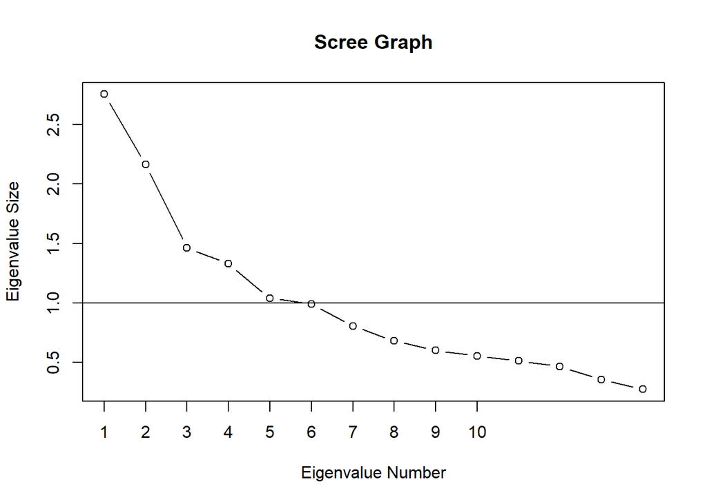

```r
plot(eigen(r)$values, xlab = 'Eigenvalue Number', ylab = 'Eigenvalue Size', main = 'Scree Graph', type = 'b', xaxt = 'n')
axis(1, at = seq(1, 10, by = 1))
abline(h = 1)
```

```r
# 5 or 6 factors should be enough.
```

#### Parallel Analysis

```r
ap = parallel(subject=nrow(data),var=ncol(data), rep=100)
(nS <- nScree(x = eigen(cor(data))$values, aparallel=ap$eigen$qevpea, model = "factors"))
```

```
##   noc naf nparallel nkaiser
## 1   4   2         4       5
```

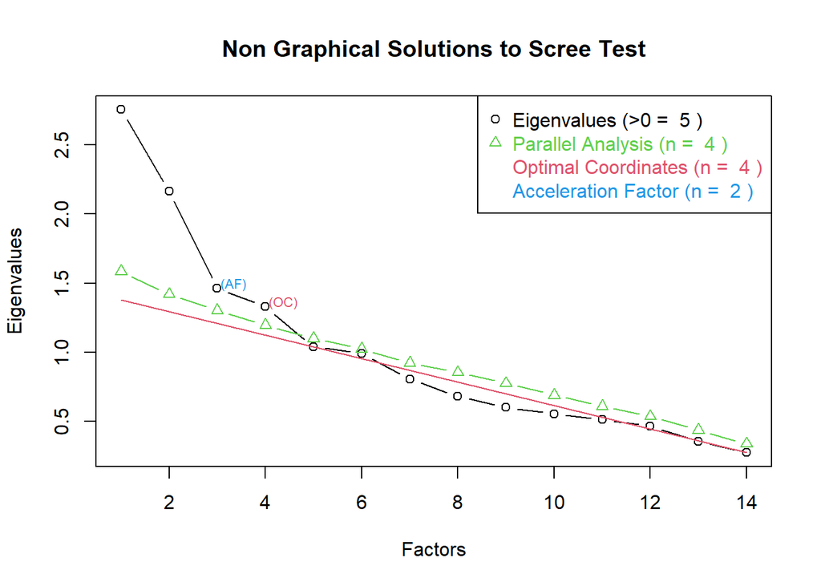

```r
plotnScree(nS)
```

```r
# Parallel analysis suggest that we should use 4 factors.
# We decided to use 5 factors based on all three methods.
```

#### Principal Function

```r
pc.fa = principal(r, nfactors = 5, rotate = "varimax")
print(pc.fa$loadings, cutoff = 0.4)
```

```
##
## Loadings:
##                     RC1    RC2    RC5    RC4    RC3
## Price                0.721
## Safety              -0.432
## Exterior_Looks                           -0.809
## Space_comfort               0.778
## Technology                  0.596
## After_Sales_Service         0.408  0.687
## Resale_Value         0.733
## Fuel_Type                   0.719
## Fuel_Efficiency      0.429         0.637
## Color                                     0.766
## Maintenance          0.685
## Test_drive                         0.718
## Product_reviews      0.415                       0.547
## Testimonials                                     0.782
##
##                  RC1   RC2   RC5   RC4   RC3
## SS loadings    2.187 1.960 1.600 1.515 1.493
## Proportion Var 0.156 0.140 0.114 0.108 0.107
## Cumulative Var 0.156 0.296 0.410 0.519 0.625
```

```r
pc.fa$residual
```

```
##                            Price      Safety Exterior_Looks Space_comfort
## Price                0.432838605  0.14722709   -0.073680298  -0.008675121
## Safety               0.147227089  0.47615999    0.070454107  -0.018494192
## Exterior_Looks      -0.073680298  0.07045411    0.291021195  -0.088820671
## Space_comfort       -0.008675121 -0.01849419   -0.088820671   0.294297676
## Technology          -0.137829057 -0.10470982    0.079272664  -0.177028336
## After_Sales_Service -0.028564170 -0.14937605    0.058873700  -0.089775335
## Resale_Value        -0.107512866  0.07158591   -0.009697678   0.009908705
## Fuel_Type           -0.051569833 -0.13895722   -0.030806116  -0.092745511
## Fuel_Efficiency      0.008243169 -0.09096129   -0.015011533   0.010315357
## Color                0.036861281  0.02800826    0.210089362  -0.002295954
## Maintenance         -0.178104464  0.04454928    0.066136715   0.036696589
## Test_drive           0.040645411  0.02269008   -0.099869813   0.010999042
## Product_reviews     -0.027078074  0.20543120   -0.053304165  -0.024365580
## Testimonials         0.111167894  0.06285936   -0.042546342  -0.028740218
##                      Technology After_Sales_Service Resale_Value   Fuel_Type
## Price               -0.13782906       -0.0285641699 -0.107512866 -0.05156983
## Safety              -0.10470982       -0.1493760459  0.071585905 -0.13895722
## Exterior_Looks       0.07927266        0.0588736995 -0.009697678 -0.03080612
## Space_comfort       -0.17702834       -0.0897753350  0.009908705 -0.09274551
## Technology           0.60582779        0.0915613291  0.074997759 -0.19287199
## After_Sales_Service  0.09156133        0.3180096815 -0.032570773 -0.10672963
## Resale_Value         0.07499776       -0.0325707729  0.291542056  0.04387165
## Fuel_Type           -0.19287199       -0.1067296274  0.043871648  0.45823197
## Fuel_Efficiency     -0.04518508       -0.0600075064 -0.083059798  0.05816456
## Color               -0.02827911       -0.0123909318 -0.004972378  0.05058742
## Maintenance          0.03836169       -0.0018241196 -0.040298165 -0.06905576
## Test_drive           0.09723035       -0.1707529894 -0.023738510  0.03965743
## Product_reviews     -0.14962843       -0.0005059926 -0.018539309 -0.08720719
## Testimonials        -0.07395185        0.0481950999  0.152208904  0.06566590
##                     Fuel_Efficiency        Color Maintenance  Test_drive
## Price                  0.0082431690  0.036861281 -0.17810446  0.04064541
## Safety                -0.0909612871  0.028008256  0.04454928  0.02269008
## Exterior_Looks        -0.0150115334  0.210089362  0.06613672 -0.09986981
## Space_comfort          0.0103153569 -0.002295954  0.03669659  0.01099904
## Technology            -0.0451850790 -0.028279112  0.03836169  0.09723035
## After_Sales_Service   -0.0600075064 -0.012390932 -0.00182412 -0.17075299
## Resale_Value          -0.0830597982 -0.004972378 -0.04029816 -0.02373851
## Fuel_Type              0.0581645635  0.050587415 -0.06905576  0.03965743
## Fuel_Efficiency        0.3222064335 -0.059696472 -0.16374502 -0.15118545
## Color                 -0.0596964722  0.270473419 -0.02520098  0.00299177
## Maintenance           -0.1637450202 -0.025200979  0.40755388  0.09817591
## Test_drive            -0.1511854489  0.002991770  0.09817591  0.32753254
## Product_reviews       -0.0038163885 -0.098257223 -0.08835925 -0.06036104
## Testimonials           0.0003152112 -0.051404658 -0.05039539 -0.12064799
##                     Product_reviews  Testimonials
## Price                 -0.0270780735  0.1111678940
## Safety                 0.2054312037  0.0628593553
## Exterior_Looks        -0.0533041654 -0.0425463417
## Space_comfort         -0.0243655801 -0.0287402182
## Technology            -0.1496284305 -0.0739518521
## After_Sales_Service   -0.0005059926  0.0481950999
## Resale_Value          -0.0185393090  0.1522089042
## Fuel_Type             -0.0872071870  0.0656659000
## Fuel_Efficiency       -0.0038163885  0.0003152112
## Color                 -0.0982572233 -0.0514046576
## Maintenance           -0.0883592477 -0.0503953858
## Test_drive            -0.0603610389 -0.1206479865
## Product_reviews        0.4532205217 -0.1110018501
## Testimonials          -0.1110018501  0.2972129426
```

```r
pc.fa$uniquenesses
```

```
##               Price              Safety      Exterior_Looks       Space_comfort
##           0.4328386           0.4761600           0.2910212           0.2942977
##          Technology After_Sales_Service        Resale_Value           Fuel_Type
##           0.6058278           0.3180097           0.2915421           0.4582320
##     Fuel_Efficiency               Color         Maintenance          Test_drive
##           0.3222064           0.2704734           0.4075539           0.3275325
##     Product_reviews        Testimonials
##           0.4532205           0.2972129
```

```r
(pc.r=pc.fa$residual - diag(pc.fa$uniquenesses))
```

```
##                             Price        Safety Exterior_Looks Space_comfort
## Price               -2.220446e-16  1.472271e-01  -7.368030e-02 -8.675121e-03
## Safety               1.472271e-01 -1.110223e-16   7.045411e-02 -1.849419e-02
## Exterior_Looks      -7.368030e-02  7.045411e-02  -6.661338e-16 -8.882067e-02
## Space_comfort       -8.675121e-03 -1.849419e-02  -8.882067e-02 -2.220446e-16
## Technology          -1.378291e-01 -1.047098e-01   7.927266e-02 -1.770283e-01
## After_Sales_Service -2.856417e-02 -1.493760e-01   5.887370e-02 -8.977534e-02
## Resale_Value        -1.075129e-01  7.158591e-02  -9.697678e-03  9.908705e-03
## Fuel_Type           -5.156983e-02 -1.389572e-01  -3.080612e-02 -9.274551e-02
## Fuel_Efficiency      8.243169e-03 -9.096129e-02  -1.501153e-02  1.031536e-02
## Color                3.686128e-02  2.800826e-02   2.100894e-01 -2.295954e-03
## Maintenance         -1.781045e-01  4.454928e-02   6.613672e-02  3.669659e-02
## Test_drive           4.064541e-02  2.269008e-02  -9.986981e-02  1.099904e-02
## Product_reviews     -2.707807e-02  2.054312e-01  -5.330417e-02 -2.436558e-02
## Testimonials         1.111679e-01  6.285936e-02  -4.254634e-02 -2.874022e-02
##                      Technology After_Sales_Service  Resale_Value     Fuel_Type
## Price               -0.13782906       -0.0285641699 -1.075129e-01 -5.156983e-02
## Safety              -0.10470982       -0.1493760459  7.158591e-02 -1.389572e-01
## Exterior_Looks       0.07927266        0.0588736995 -9.697678e-03 -3.080612e-02
## Space_comfort       -0.17702834       -0.0897753350  9.908705e-03 -9.274551e-02
## Technology           0.00000000        0.0915613291  7.499776e-02 -1.928720e-01
## After_Sales_Service  0.09156133        0.0000000000 -3.257077e-02 -1.067296e-01
## Resale_Value         0.07499776       -0.0325707729 -4.440892e-16  4.387165e-02
## Fuel_Type           -0.19287199       -0.1067296274  4.387165e-02 -2.220446e-16
## Fuel_Efficiency     -0.04518508       -0.0600075064 -8.305980e-02  5.816456e-02
## Color               -0.02827911       -0.0123909318 -4.972378e-03  5.058742e-02
## Maintenance          0.03836169       -0.0018241196 -4.029816e-02 -6.905576e-02
## Test_drive           0.09723035       -0.1707529894 -2.373851e-02  3.965743e-02
## Product_reviews     -0.14962843       -0.0005059926 -1.853931e-02 -8.720719e-02
## Testimonials        -0.07395185        0.0481950999  1.522089e-01  6.566590e-02
##                     Fuel_Efficiency        Color   Maintenance    Test_drive
## Price                  8.243169e-03  0.036861281 -1.781045e-01  4.064541e-02
## Safety                -9.096129e-02  0.028008256  4.454928e-02  2.269008e-02
## Exterior_Looks        -1.501153e-02  0.210089362  6.613672e-02 -9.986981e-02
## Space_comfort          1.031536e-02 -0.002295954  3.669659e-02  1.099904e-02
## Technology            -4.518508e-02 -0.028279112  3.836169e-02  9.723035e-02
## After_Sales_Service   -6.000751e-02 -0.012390932 -1.824120e-03 -1.707530e-01
## Resale_Value          -8.305980e-02 -0.004972378 -4.029816e-02 -2.373851e-02
## Fuel_Type              5.816456e-02  0.050587415 -6.905576e-02  3.965743e-02
## Fuel_Efficiency       -3.330669e-16 -0.059696472 -1.637450e-01 -1.511854e-01
## Color                 -5.969647e-02  0.000000000 -2.520098e-02  2.991770e-03
## Maintenance           -1.637450e-01 -0.025200979 -2.220446e-16  9.817591e-02
## Test_drive            -1.511854e-01  0.002991770  9.817591e-02 -3.330669e-16
## Product_reviews       -3.816389e-03 -0.098257223 -8.835925e-02 -6.036104e-02
## Testimonials           3.152112e-04 -0.051404658 -5.039539e-02 -1.206480e-01
##                     Product_reviews  Testimonials
## Price                 -2.707807e-02  1.111679e-01
## Safety                 2.054312e-01  6.285936e-02
## Exterior_Looks        -5.330417e-02 -4.254634e-02
## Space_comfort         -2.436558e-02 -2.874022e-02
## Technology            -1.496284e-01 -7.395185e-02
## After_Sales_Service   -5.059926e-04  4.819510e-02
## Resale_Value          -1.853931e-02  1.522089e-01
## Fuel_Type             -8.720719e-02  6.566590e-02
## Fuel_Efficiency       -3.816389e-03  3.152112e-04
## Color                 -9.825722e-02 -5.140466e-02
## Maintenance           -8.835925e-02 -5.039539e-02
## Test_drive            -6.036104e-02 -1.206480e-01
## Product_reviews       -2.220446e-16 -1.110019e-01
## Testimonials          -1.110019e-01 -1.110223e-16
```

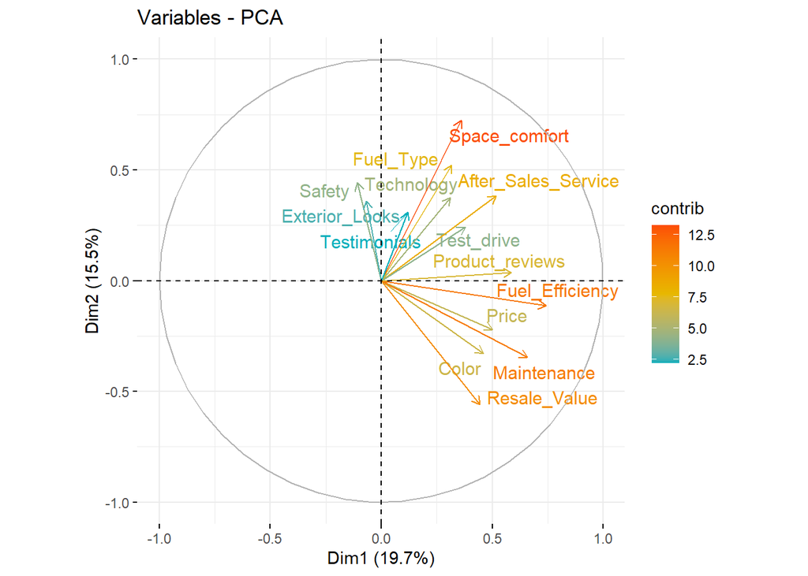

```r
res.pca <- prcomp(data, scale = TRUE)
fviz_pca_var(res.pca,
             col.var = "contrib",
             gradient.cols = c("#00AFBB", "#E7B800", "#FC4E07"),
             repel = TRUE
             )
```

#### Factanal Function

```r
mle.fa = factanal(covmat = r,factors = 5, rotation = "varimax")
mle.fa$loadings
```

```
##
## Loadings:
##                     Factor1 Factor2 Factor3 Factor4 Factor5
## Price                0.562   0.112
## Safety              -0.265   0.325          -0.171   0.140
## Exterior_Looks                      -0.390   0.169
## Space_comfort                0.899  -0.180   0.233
## Technology                   0.300                   0.185
## After_Sales_Service          0.332                   0.934
## Resale_Value         0.699  -0.222          -0.138   0.122
## Fuel_Type                    0.515
## Fuel_Efficiency      0.468           0.183   0.301   0.352
## Color                0.173           0.945   0.259
## Maintenance          0.614           0.265
## Test_drive                                   0.424   0.161
## Product_reviews      0.365   0.141           0.437
## Testimonials        -0.212                   0.668
##
##                Factor1 Factor2 Factor3 Factor4 Factor5
## SS loadings      1.702   1.486   1.191   1.123   1.109
## Proportion Var   0.122   0.106   0.085   0.080   0.079
## Cumulative Var   0.122   0.228   0.313   0.393   0.472
```

```r
# 0.1 as default cut off point, covmat  = correlation
# cut off point = (2*p)/n = 0.31 approximately 0.3
print(mle.fa, digits = 2, cutoff=.3, sort = TRUE)
```

```
##
## Call:
## factanal(factors = 5, covmat = r, rotation = "varimax")
##
## Uniquenesses:
##               Price              Safety      Exterior_Looks       Space_comfort
##                0.67                0.77                0.81                0.10
##          Technology After_Sales_Service        Resale_Value           Fuel_Type
##                0.87                0.00                0.43                0.72
##     Fuel_Efficiency               Color         Maintenance          Test_drive
##                0.53                0.00                0.54                0.78
##     Product_reviews        Testimonials
##                0.65                0.51
##
## Loadings:
##                     Factor1 Factor2 Factor3 Factor4 Factor5
## Price                0.56
## Resale_Value         0.70
## Maintenance          0.61
## Space_comfort                0.90
## Fuel_Type                    0.52
## Color                                0.95
## Testimonials                                 0.67
## After_Sales_Service          0.33                    0.93
## Safety                       0.33
## Exterior_Looks                      -0.39
## Technology                   0.30
## Fuel_Efficiency      0.47                    0.30    0.35
## Test_drive                                   0.42
## Product_reviews      0.37                    0.44
##
##                Factor1 Factor2 Factor3 Factor4 Factor5
## SS loadings       1.70    1.49    1.19    1.12    1.11
## Proportion Var    0.12    0.11    0.09    0.08    0.08
## Cumulative Var    0.12    0.23    0.31    0.39    0.47
##
## The degrees of freedom for the model is 31 and the fit was 0.3171
```

```r
#total variance explained is 47%, worse than PCA method in fitting factoial analysis.

#Factor 1 is highly correlated with Resale_Value and maintenance. This is primarily a measurement of loss; Fact 2 is highly correlated with space_comfort. This is primarily a measurement of reliability. Factor 3 is highly correlated with color. This is primarily a measurement of appearance. Factor 4 is highly correlated with testimonials. This is primarily a measurement of advertisement. Factor 5 is highly correlated with After_Sales_Service. This is primarily a measurement of cost effectiveness

#Factor 1 accounts for 12% of variance and factor 5 accounts for 8%. The total variance is 47.2% by factorial explaination.

# Specific variance
(Psi = diag(mle.fa$uniquenesses))
```

```
##            [,1]      [,2]      [,3]      [,4]    [,5]  [,6]      [,7]      [,8]
##  [1,] 0.6708962 0.0000000 0.0000000 0.0000000 0.00000 0.000 0.0000000 0.0000000
##  [2,] 0.0000000 0.7737925 0.0000000 0.0000000 0.00000 0.000 0.0000000 0.0000000
##  [3,] 0.0000000 0.0000000 0.8133697 0.0000000 0.00000 0.000 0.0000000 0.0000000
##  [4,] 0.0000000 0.0000000 0.0000000 0.1035552 0.00000 0.000 0.0000000 0.0000000
##  [5,] 0.0000000 0.0000000 0.0000000 0.0000000 0.86738 0.000 0.0000000 0.0000000
##  [6,] 0.0000000 0.0000000 0.0000000 0.0000000 0.00000 0.005 0.0000000 0.0000000
##  [7,] 0.0000000 0.0000000 0.0000000 0.0000000 0.00000 0.000 0.4282693 0.0000000
##  [8,] 0.0000000 0.0000000 0.0000000 0.0000000 0.00000 0.000 0.0000000 0.7201756
##  [9,] 0.0000000 0.0000000 0.0000000 0.0000000 0.00000 0.000 0.0000000 0.0000000
## [10,] 0.0000000 0.0000000 0.0000000 0.0000000 0.00000 0.000 0.0000000 0.0000000
## [11,] 0.0000000 0.0000000 0.0000000 0.0000000 0.00000 0.000 0.0000000 0.0000000
## [12,] 0.0000000 0.0000000 0.0000000 0.0000000 0.00000 0.000 0.0000000 0.0000000
## [13,] 0.0000000 0.0000000 0.0000000 0.0000000 0.00000 0.000 0.0000000 0.0000000
## [14,] 0.0000000 0.0000000 0.0000000 0.0000000 0.00000 0.000 0.0000000 0.0000000
##            [,9] [,10]     [,11]     [,12]     [,13]    [,14]
##  [1,] 0.0000000 0.000 0.0000000 0.0000000 0.0000000 0.000000
##  [2,] 0.0000000 0.000 0.0000000 0.0000000 0.0000000 0.000000
##  [3,] 0.0000000 0.000 0.0000000 0.0000000 0.0000000 0.000000
##  [4,] 0.0000000 0.000 0.0000000 0.0000000 0.0000000 0.000000
##  [5,] 0.0000000 0.000 0.0000000 0.0000000 0.0000000 0.000000
##  [6,] 0.0000000 0.000 0.0000000 0.0000000 0.0000000 0.000000
##  [7,] 0.0000000 0.000 0.0000000 0.0000000 0.0000000 0.000000
##  [8,] 0.0000000 0.000 0.0000000 0.0000000 0.0000000 0.000000
##  [9,] 0.5263475 0.000 0.0000000 0.0000000 0.0000000 0.000000
## [10,] 0.0000000 0.005 0.0000000 0.0000000 0.0000000 0.000000
## [11,] 0.0000000 0.000 0.5380306 0.0000000 0.0000000 0.000000
## [12,] 0.0000000 0.000 0.0000000 0.7756691 0.0000000 0.000000
## [13,] 0.0000000 0.000 0.0000000 0.0000000 0.6547265 0.000000
## [14,] 0.0000000 0.000 0.0000000 0.0000000 0.0000000 0.506727
```